# Project Assignment Machine Learning Course - ND

21 December 2015

## Executive Summary

As a part of human activity recognition research a team has provided a Weight Lifting Exercises dataset to investigate “how (well)” an activity was performed by the wearer. Six young health participants were asked to perform one set of 10 repetitions of the Unilateral Dumbbell Biceps Curl in five different fashions: exactly according to the specification (Class A), throwing the elbows to the front (Class B), lifting the dumbbell only halfway (Class C), lowering the dumbbell only halfway (Class D) and throwing the hips to the front (Class E). Class A corresponds to the specified execution of the exercise, while the other 4 classes correspond to common mistakes. The goal of this machine learning exercise was to predict the manner of doing the exercise. This assignment describes the steps used to build the model including exploratory data analysis, creating a model on the training data set with cross-validation. The model arrived at has been tested with the sample test data sets provided. Results have been summarized in this report.

## Input Data analysis

The training data is in the file pml-training.csv.

```r
library(caret)
library(e1071)
library(randomForest)
```

```r
library(corrplot)
 f1 <- "c:/users/diwakarn/Desktop/Diwakar/rstuff/ml/pml-training.csv"
 pmldf <-  read.csv(f1,header = TRUE, sep ="," )
```

Examination of the data frame shows that there are lot of columns with NA or with most of values being 0. So data has to cleaned to remove such columns. The first 7 columns relate to descriptive information about the measurements and can be removed for building the prediction model.

```r
#clean data and get useful columns
pmldf <- pmldf[,8:length(pmldf)]
pmldf1 <- nearZeroVar(pmldf,saveMetrics = TRUE)
pmldf2 <-pmldf[,!pmldf1$nzv]
paste ("The number of rows and columns in the cleaned training data is")
```

```
## [1] "The number of rows and columns in the cleaned training data is"
```

```r
dim(pmldf2)
```

```
## [1] 19622    53
```

## Creating the training and cross validation data sets

The first step is to create the training data set and a cross validation data set from the cleaned data.

```r
#Create Training data sets and Cross Validation Data Set

inTrain = createDataPartition(pmldf2$classe, p = 3/4)[[1]]
training = pmldf2[ inTrain,]
crossval = pmldf2[-inTrain,]
```

Carrying out a correlation between the prediction variables …

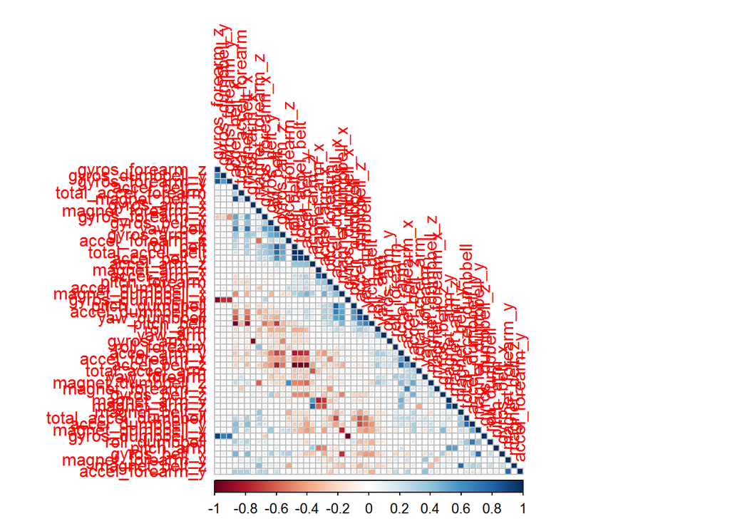

```r
#Correlation matrix for the training data set

correlMatrix <- cor(training[,1:52])
corrplot(correlMatrix,order = "AOE",type = "lower",method = "square")
```

The Correlation shows that there are strongly corelated variables and there is an opportunity to reduce the predictor variables

## Building the Prediction Model

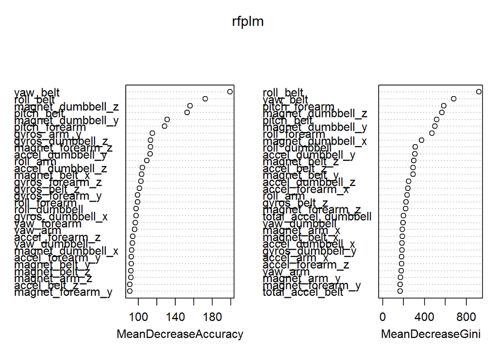

```r
rfplm <-randomForest(classe~ ., data=training,importance =TRUE,proximity=TRUE,ntree=5000,preProcessing = "pca")
varImpPlot(rfplm)
```

```r
# Cross Validation
rfplmpred <- predict(rfplm,crossval)
confusionMatrix(crossval$classe,rfplmpred)
```

```
## Confusion Matrix and Statistics
##
##           Reference
## Prediction    A    B    C    D    E
##          A 1393    2    0    0    0
##          B    6  942    1    0    0
##          C    0    4  851    0    0
##          D    0    0    3  801    0
##          E    0    0    1    2  898
##
## Overall Statistics
##
##                Accuracy : 0.9961
##                  95% CI : (0.994, 0.9977)
##     No Information Rate : 0.2853
##     P-Value [Acc > NIR] : < 2.2e-16
##
##                   Kappa : 0.9951
##  Mcnemar's Test P-Value : NA
##
## Statistics by Class:
##
##                      Class: A Class: B Class: C Class: D Class: E
## Sensitivity            0.9957   0.9937   0.9942   0.9975   1.0000
## Specificity            0.9994   0.9982   0.9990   0.9993   0.9993
## Pos Pred Value         0.9986   0.9926   0.9953   0.9963   0.9967
## Neg Pred Value         0.9983   0.9985   0.9988   0.9995   1.0000
## Prevalence             0.2853   0.1933   0.1746   0.1637   0.1831
## Detection Rate         0.2841   0.1921   0.1735   0.1633   0.1831
## Detection Prevalence   0.2845   0.1935   0.1743   0.1639   0.1837
## Balanced Accuracy      0.9976   0.9960   0.9966   0.9984   0.9996
```

Results of the confusion matrix shows that the accuracy is very high @95% confidence interval .

## Running predictions against testing data

The test data is available in the pml-testing.csv data set. As in the training data set, there are many columns with NAs. Data cleanup is now done before carrying out the prediction and prediction is carried out.

```r
f1 <- "c:/users/diwakarn/Desktop/Diwakar/rstuff/ml/pml-testing.csv"
pmltdf <-  read.csv(f1,header = TRUE, sep ="," )
pmltdf <- pmltdf[,8:length(pmltdf)]
#Remove NA columns
pmltdf2 <- pmltdf[, colSums(is.na(pmltdf)) != nrow(pmltdf)]
rfplmpred <- predict(rfplm,pmltdf2)
print(rfplmpred)
```

```
##  1  2  3  4  5  6  7  8  9 10 11 12 13 14 15 16 17 18 19 20
##  B  A  B  A  A  E  D  B  A  A  B  C  B  A  E  E  A  B  B  B
## Levels: A B C D E
```

Generating answer files required for submission

```r
answer<- as.character(levels(rfplmpred))[rfplmpred]

#pml_write_files = function(x){
 # n = length(x)
 # for(i in 1:n){
 #   filename = paste0("problem_id_",i,".txt")
 #   write.table(x[i],file=filename,quote=FALSE,row.names=FALSE,col.names=FALSE)
 # }
#}

#pml_write_files(answer)
```